# R的数据管理之一

李峰

2017年3月15日

## 1. 数据合并和整合

- 对数据框，根据关键字的合并，使用*merge*函数

```r
ReportCard1<-read.table(file="ReportCard1.txt",header=TRUE)
names(ReportCard1)
```

```
## [1] "xh"   "sex"  "poli" "chi"  "math"
```

```r
ReportCard2<-read.table(file="ReportCard2.txt",header=TRUE)
names(ReportCard2)
```

```
## [1] "xh"   "fore" "phy"  "che"  "geo"  "his"
```

```r
ReportCard<-merge(ReportCard1,ReportCard2,by="xh")
names(ReportCard)
```

```
##  [1] "xh"   "sex"  "poli" "chi"  "math" "fore" "phy"  "che"  "geo"  "his"
```

```r
fix(ReportCard)
```

- 对矩阵，可根据行向进行合并，使用*cbind*函数，使用前保证有相同的行排列顺序

数据的aggregate

```r
options(digits=3)
attach(mtcars)
aggdata <-aggregate(mtcars, by=list(cyl,gear),
    FUN=mean, na.rm=TRUE)                      # FUN是函数
aggdata
```

```
##   Group.1 Group.2  mpg cyl disp  hp drat   wt qsec  vs   am gear carb
## 1       4       3 21.5   4  120  97 3.70 2.46 20.0 1.0 0.00    3 1.00
## 2       6       3 19.8   6  242 108 2.92 3.34 19.8 1.0 0.00    3 1.00
## 3       8       3 15.1   8  358 194 3.12 4.10 17.1 0.0 0.00    3 3.08
## 4       4       4 26.9   4  103  76 4.11 2.38 19.6 1.0 0.75    4 1.50
## 5       6       4 19.8   6  164 116 3.91 3.09 17.7 0.5 0.50    4 4.00
## 6       4       5 28.2   4  108 102 4.10 1.83 16.8 0.5 1.00    5 2.00
## 7       6       5 19.7   6  145 175 3.62 2.77 15.5 0.0 1.00    5 6.00
## 8       8       5 15.4   8  326 300 3.88 3.37 14.6 0.0 1.00    5 6.00
```

```r
mtcars
```

```
##                      mpg cyl  disp  hp drat   wt qsec vs am gear carb
## Mazda RX4           21.0   6 160.0 110 3.90 2.62 16.5  0  1    4    4
## Mazda RX4 Wag       21.0   6 160.0 110 3.90 2.88 17.0  0  1    4    4
## Datsun 710          22.8   4 108.0  93 3.85 2.32 18.6  1  1    4    1
## Hornet 4 Drive      21.4   6 258.0 110 3.08 3.21 19.4  1  0    3    1
## Hornet Sportabout   18.7   8 360.0 175 3.15 3.44 17.0  0  0    3    2
## Valiant             18.1   6 225.0 105 2.76 3.46 20.2  1  0    3    1
## Duster 360          14.3   8 360.0 245 3.21 3.57 15.8  0  0    3    4
## Merc 240D           24.4   4 146.7  62 3.69 3.19 20.0  1  0    4    2
## Merc 230            22.8   4 140.8  95 3.92 3.15 22.9  1  0    4    2
## Merc 280            19.2   6 167.6 123 3.92 3.44 18.3  1  0    4    4
## Merc 280C           17.8   6 167.6 123 3.92 3.44 18.9  1  0    4    4
## Merc 450SE          16.4   8 275.8 180 3.07 4.07 17.4  0  0    3    3
## Merc 450SL          17.3   8 275.8 180 3.07 3.73 17.6  0  0    3    3
## Merc 450SLC         15.2   8 275.8 180 3.07 3.78 18.0  0  0    3    3
## Cadillac Fleetwood  10.4   8 472.0 205 2.93 5.25 18.0  0  0    3    4
## Lincoln Continental 10.4   8 460.0 215 3.00 5.42 17.8  0  0    3    4
## Chrysler Imperial   14.7   8 440.0 230 3.23 5.34 17.4  0  0    3    4
## Fiat 128            32.4   4  78.7  66 4.08 2.20 19.5  1  1    4    1
## Honda Civic         30.4   4  75.7  52 4.93 1.61 18.5  1  1    4    2
## Toyota Corolla      33.9   4  71.1  65 4.22 1.83 19.9  1  1    4    1
## Toyota Corona       21.5   4 120.1  97 3.70 2.46 20.0  1  0    3    1
## Dodge Challenger    15.5   8 318.0 150 2.76 3.52 16.9  0  0    3    2
## AMC Javelin         15.2   8 304.0 150 3.15 3.44 17.3  0  0    3    2
## Camaro Z28          13.3   8 350.0 245 3.73 3.84 15.4  0  0    3    4
## Pontiac Firebird    19.2   8 400.0 175 3.08 3.85 17.1  0  0    3    2
## Fiat X1-9           27.3   4  79.0  66 4.08 1.94 18.9  1  1    4    1
## Porsche 914-2       26.0   4 120.3  91 4.43 2.14 16.7  0  1    5    2
## Lotus Europa        30.4   4  95.1 113 3.77 1.51 16.9  1  1    5    2
## Ford Pantera L      15.8   8 351.0 264 4.22 3.17 14.5  0  1    5    4
## Ferrari Dino        19.7   6 145.0 175 3.62 2.77 15.5  0  1    5    6
## Maserati Bora       15.0   8 301.0 335 3.54 3.57 14.6  0  1    5    8
## Volvo 142E          21.4   4 121.0 109 4.11 2.78 18.6  1  1    4    2
```

## 2. 数据排序

- 数据的排序可以帮助我们很快找到缺失值。
- R的排序功能返回一个位置向量，和MATLAB一样，这个功能可先对一个矩阵按照某列进行排序，得到位置向量，再要求另一个矩阵按照这个顺序进行排列，保证两个矩阵都按照相同的顺序按行排列。

```r
Ord<-order(ReportCard$math,na.last=TRUE,decreasing=TRUE)
# na.last=TRUE，表示缺失值排最后，若参数值是FALSE，则排最前，若NA，则不参与排序
# decreasing选择升序还是降序
Ord
```

```
##  [1]  1 33  2 32 34 31 14  5  6 35 10 45  9 12  8 36 38 46  4  7 44 39 13
## [24] 50 11 49 41 16 37 43 42 40 17 47 27 19 58 15 18 52 20 57 22 23 24 48
## [47] 54 21 30 51 53 55 60 26 25 56 28 59 29  3
```

```r
a<-ReportCard[Ord,]
fix(a)
```

```r
Ord<-order(+ReportCard$sex,-ReportCard$math,na.last=TRUE)
# 对sex升序，对math降序
Ord
```

```
##  [1]  2 31 14  5  9 12  8 46 44 11 49 41 16 37 43 42 40 17 19 58 15 52 24
## [24] 54 30 51 53 28 59 29  1 33 32 34  6 35 10 45 36 38  4  7 39 13 50 47
## [47] 27 18 20 57 22 23 48 21 55 60 26 25 56  3
```

```r
a<-ReportCard[Ord,]
fix(a)
```

## 3.缺失数据报告

- R的缺失也有两类，sysmis和user missing，前者是*NA*(Not Avaliable)，后者是*NaN*(Not a Number)。
- 判断缺失值，使用*is.na*和*is.nan*，对向量中的每个元素做判断，*is.na*返回的结果包含NaN。

```r
a<-is.na(ReportCard$math)
# 若存在na，则返回TRUE
ReportCard[a,]
```

```
##      xh sex poli chi math fore phy che geo his
## 3 92103   2   NA  NA   NA   66  98  79  89  81
```

- 判断矩阵或数据框的每一行是否有缺失

```r
a<-complete.cases(ReportCard)
# 若此行无缺失，则返回TRUE，有则返回FALSE
ReportCard[!a,]
```

```
##       xh sex poli chi math fore phy che geo his
## 3  92103   2   NA  NA   NA   66  98  79  89  81
## 27 92142   2  NaN  70   59   22  68  26  26  63
```

```r
# !是“否”的运算符，!a表示将有有缺失的数据列出
```

- 得到缺失报告

```r
# install.packages("mice")
library("mice")
md.pattern(ReportCard) # 注意，这真的是个pattern
```

```
##    xh sex fore phy che geo his chi math poli
## 58  1   1    1   1   1   1   1   1    1    1 0
##  1  1   1    1   1   1   1   1   1    1    0 1
##  1  1   1    1   1   1   1   1   0    0    0 3
##     0   0    0   0   0   0   0   1    1    2 4
```

- 如何处理缺失数据

```r
ReportCard<-na.omit(ReportCard) # 相对于pairwise，简单粗暴的listwise
md.pattern(ReportCard)
```

```
##      xh sex poli chi math fore phy che geo his
## [1,]  1   1    1   1    1    1   1   1   1   1 0
## [2,]  0   0    0   0    0    0   0   0   0   0 0
```

## 4. 变量计算

- 对象的基本运算

```r
attach(ReportCard)           # 将变量框读到内存，你行你上
SumScore<-poli+chi+math+fore+phy+che+geo+his
detach(ReportCard)           # 将变量框从内存施放出来，不行下来
AvScore<-SumScore/8
ReportCard$sumScore<-SumScore
ReportCard$avScore<-AvScore
names(ReportCard)
```

```
##  [1] "xh"       "sex"      "poli"     "chi"      "math"     "fore"
##  [7] "phy"      "che"      "geo"      "his"      "sumScore" "avScore"
```

```r
fix(ReportCard)
a<-is.na(ReportCard$sumScore) # is.na返回的结果包含NaN
ReportCard[a,]
```

```
##  [1] xh       sex      poli     chi      math     fore     phy
##  [8] che      geo      his      sumScore avScore
## <0 rows> (or 0-length row.names)
```

```r
sum(is.na(ReportCard$sumScore))
```

```
## [1] 0
```

```r
mean(complete.cases(ReportCard$sumScore)) # 这算的是个啥？
```

```
## [1] 1
```

```r
a <- 5
sqrt(a)
```

```
## [1] 2.24
```

```r
b <- c(1.243, 5.654, 2.99)
round(b)
```

```
## [1] 1 6 3
```

```r
c <- matrix(runif(12), nrow=3)
c
```

```
##        [,1]  [,2]  [,3]   [,4]
## [1,] 0.3716 0.637 0.923 0.6317
## [2,] 0.0298 0.805 0.290 0.0792
## [3,] 0.8260 0.379 0.380 0.8645
```

```r
log(c)  #自然对数
```

```
##        [,1]   [,2]    [,3]   [,4]
## [1,] -0.990 -0.450 -0.0804 -0.459
## [2,] -3.513 -0.217 -1.2379 -2.536
## [3,] -0.191 -0.969 -0.9681 -0.146
```

```r
log10(c)
```

```
##        [,1]    [,2]    [,3]    [,4]
## [1,] -0.430 -0.1956 -0.0349 -0.1995
## [2,] -1.526 -0.0943 -0.5376 -1.1015
## [3,] -0.083 -0.4209 -0.4204 -0.0632
```

```r
mean(c)
```

```
## [1] 0.518
```

```r
x <- c(1, 2, 3, 4, 5, 6, 7, 8)
mean(x)
```

```
## [1] 4.5
```

```r
sd(x)
```

```
## [1] 2.45
```

```r
n <- length(x)
meanx <- sum(x)/n
css <- sum((x - meanx)**2)
sdx <- sqrt(css / (n-1))
meanx
```

```
## [1] 4.5
```

```r
sdx
```

```
## [1] 2.45
```

利用apply求各列均值

```r
mydata <- matrix(rnorm(30), nrow=6)
mydata
```

```
##         [,1]   [,2]   [,3]   [,4]   [,5]
## [1,] -0.3570  0.338 -0.165  0.290 -0.106
## [2,] -0.8207 -0.696  0.856  0.849  1.774
## [3,]  1.1204  0.131  1.114  1.472  0.188
## [4,] -0.0609 -0.155  1.343  0.289 -1.156
## [5,]  0.6044 -0.437  0.123 -0.617  1.192
## [6,] -0.4522 -0.772 -1.519  0.599 -0.570
```

```r
apply(mydata, 1, mean)             # 行均值
```

```
## [1]  0.000149  0.392398  0.805048  0.052117  0.173186 -0.542825
```

```r
apply(mydata, 2, mean)             # 列均值
```

```
## [1]  0.00567 -0.26509  0.29207  0.48023  0.22051
```

```r
apply(mydata, 2, mean, trim=.2)    # 截尾的列均值，最高和最低的20%被忽略
```

```
## [1] -0.0664 -0.2893  0.4820  0.5066  0.1761
```

- 概率函数

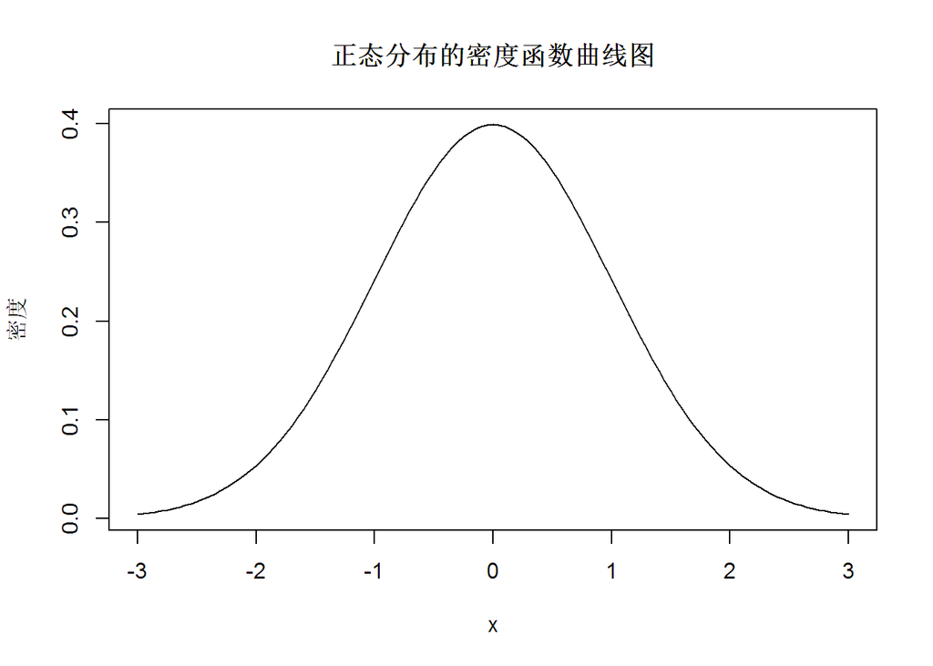

```r
x<-seq(from=-3,to=3,by=0.05)
y<-dnorm(x,0,1)
plot(x,y,type="l",ylab="密度",main="正态分布的密度函数曲线图")
```

伪随机数

```r
runif(5)
```

```
## [1] 0.136 0.522 0.480 0.916 0.604
```

```r
runif(5)
```

```
## [1] 0.993 0.776 0.407 0.302 0.389
```

```r
set.seed(1234)
runif(5)
```

```
## [1] 0.114 0.622 0.609 0.623 0.861
```

```r
set.seed(1234)
runif(5)
```

```
## [1] 0.114 0.622 0.609 0.623 0.861
```

多元正态分布

```r
# install.packages("MASS")
library(MASS)
mean <- c(230.7, 146.7, 3.6)
sigma <- matrix( c(15360.8, 6721.2, -47.1,
                    6721.2, 4700.9, -16.5,
                     -47.1,  -16.5,   0.3), nrow=3, ncol=3)

mydata <- mvrnorm(500, mean, sigma)
mydata <- as.data.frame(mydata)
names(mydata) <- c("y", "x1", "x2")

dim(mydata)
```

```
## [1] 500   3
```

```r
head(mydata, n=10)
```

```
##        y    x1   x2
## 1  270.2 177.6 3.71
## 2  120.4 145.9 3.29
## 3  272.6  71.3 3.12
## 4  263.1 115.1 3.98
## 5  414.1 215.1 2.67
## 6  343.4 221.7 3.19
## 7  160.2  97.3 4.01
## 8  158.5  66.8 3.50
## 9  163.9 122.8 4.22
## 10  49.3 -26.9 3.24
```

- 用户自定义函数

```r
MyFun<-function(dataname1=x1,dataname2=x2,key=c){
 result<-merge(dataname1,dataname2,by=key)
 return(result)
}

# 函数名 myfun  R是你的快乐？
# function 是命令
# 小括号里是形参
# 大括号里是函数体，就是函数的功能部分，函数体部分是局部变量，仅存在于你的小世界（大括号里）
# return 是函数调用的结果返回
# 先定义，再调用
```

```r
MyData<-MyFun(dataname1=ReportCard1,dataname2=ReportCard2,key="xh")
MyData<-MyFun(ReportCard1,ReportCard2,"xh")   # 这个调用有点随意
```

- 矩阵合并

```r
(m1<-matrix(1,nrow=2,ncol=2))
```

```
##      [,1] [,2]
## [1,]    1    1
## [2,]    1    1
```

```r
(m2<-matrix(2,nrow=2,ncol=2))
```

```
##      [,1] [,2]
## [1,]    2    2
## [2,]    2    2
```

```r
(mm1<-cbind(m1,m2))
```

```
##      [,1] [,2] [,3] [,4]
## [1,]    1    1    2    2
## [2,]    1    1    2    2
```

```r
(mm2<-rbind(m1,m2))
```

```
##      [,1] [,2]
## [1,]    1    1
## [2,]    1    1
## [3,]    2    2
## [4,]    2    2
```

- 矩阵乘法

```r
(mm3<-mm1%*%mm2)
```

```
##      [,1] [,2]
## [1,]   10   10
## [2,]   10   10
```

```r
(mm3<-mm2%*%mm1)
```

```
##      [,1] [,2] [,3] [,4]
## [1,]    2    2    4    4
## [2,]    2    2    4    4
## [3,]    4    4    8    8
## [4,]    4    4    8    8
```

- 矩阵创建

```r
diag(8)  #创建8乘8的单位阵
```

```
##      [,1] [,2] [,3] [,4] [,5] [,6] [,7] [,8]
## [1,]    1    0    0    0    0    0    0    0
## [2,]    0    1    0    0    0    0    0    0
## [3,]    0    0    1    0    0    0    0    0
## [4,]    0    0    0    1    0    0    0    0
## [5,]    0    0    0    0    1    0    0    0
## [6,]    0    0    0    0    0    1    0    0
## [7,]    0    0    0    0    0    0    1    0
## [8,]    0    0    0    0    0    0    0    1
```

```r
diag(c(1,2,3,4))
```

```
##      [,1] [,2] [,3] [,4]
## [1,]    1    0    0    0
## [2,]    0    2    0    0
## [3,]    0    0    3    0
## [4,]    0    0    0    4
```

```r
diag(c(1,2,3,4),nrow=3,ncol=4)
```

```
##      [,1] [,2] [,3] [,4]
## [1,]    1    0    0    0
## [2,]    0    2    0    0
## [3,]    0    0    3    0
```

- 访问正对角元素

```r
diag(mm3)  ##提取对角元素
```

```
## [1] 2 2 8 8
```

```r
diag(mm3)<-10
mm3
```

```
##      [,1] [,2] [,3] [,4]
## [1,]   10    2    4    4
## [2,]    2   10    4    4
## [3,]    4    4   10    8
## [4,]    4    4    8   10
```

```r
diag(mm3)<-c(1,2,3,4)
mm3
```

```
##      [,1] [,2] [,3] [,4]
## [1,]    1    2    4    4
## [2,]    2    2    4    4
## [3,]    4    4    3    8
## [4,]    4    4    8    4
```

- 矩阵转置

```r
(mm3<-matrix(1:9,nrow=3,ncol=3,byrow=TRUE))
```

```
##      [,1] [,2] [,3]
## [1,]    1    2    3
## [2,]    4    5    6
## [3,]    7    8    9
```

```r
t(mm3)
```

```
##      [,1] [,2] [,3]
## [1,]    1    4    7
## [2,]    2    5    8
## [3,]    3    6    9
```

- 求逆

```r
mm3<-diag(c(1,2,3,4))
solve(mm3)   ##求矩阵mm4的逆矩阵
```

```
##      [,1] [,2]  [,3] [,4]
## [1,]    1  0.0 0.000 0.00
## [2,]    0  0.5 0.000 0.00
## [3,]    0  0.0 0.333 0.00
## [4,]    0  0.0 0.000 0.25
```

- 求特征根和特征向量

```r
eigen(mm3)  ##求矩阵的特征值和特征向量
```

```
## $values
## [1] 4 3 2 1
##
## $vectors
##      [,1] [,2] [,3] [,4]
## [1,]    0    0    0    1
## [2,]    0    0    1    0
## [3,]    0    1    0    0
## [4,]    1    0    0    0
```

rm(m1,m2,mm1,mm2,mm3)

## 5. 变量的RECODE

- 对连续变量进行分类

```r
ReportCard<-within(ReportCard,{
 avScore[avScore>=90]<-"A"
 avScore[avScore>=80 & avScore<90]<-"B"
 avScore[avScore>=70 & avScore<80]<-"C"
 avScore[avScore>=60 & avScore<70]<-"D"
 avScore[avScore<60]<-"E"
 })
flag<-ReportCard$avScore %in% c("A","B","C","D","E")
ReportCard$avScore[!flag]<-NA
```

- 重新定义类别

```r
unique(ReportCard$sex)   #获得性别的取值，检查性别取值范围是否正确
```

```
## [1] 2 1
```

```r
ReportCard$sex<-factor(ReportCard$sex,levels=c(1,2),labels=c("M","F"))
str(ReportCard$sex)
```

```
##  Factor w/ 2 levels "M","F": 2 1 2 1 2 2 1 1 2 1 ...
```

- 把某些值编码为缺失值

```r
leadership[leadership$age == 99, "age"] <- NA
leadership
```

```
##   manager     date gender age q1 q2 q3 q4 q5
## 1       1 10/24/08      M  32  5  4  5  5  5
## 2       2 10/28/08      F  45  3  5  2  5  5
## 3       3  10/1/08      F  25  3  5  5  5  2
## 4       4 10/12/08      M  39  3  3  4 NA NA
## 5       5   5/1/09      F  NA  2  2  1  2  1
```

```r
aa<-complete.cases(leadership)
leadership[!aa,]
```

```
##   manager     date gender age q1 q2 q3 q4 q5
## 4       4 10/12/08      M  39  3  3  4 NA NA
## 5       5   5/1/09      F  NA  2  2  1  2  1
```

另一个例子

```r
leadership$agecat[leadership$age > 75] <- "Elder"
leadership$agecat[leadership$age > 45 &
    leadership$age <= 75] <- "Middle Aged"
leadership$agecat[leadership$age <= 45] <- "Young"
```

```r
leadership <- within(leadership, {
    agecat <- NA
    agecat[age > 75] <- "Elder"
    agecat[age >= 55 & age <= 75] <- "Middle Aged"
    agecat[age < 55] <- "Young"
})
```

## 6. 其他

- 变量重命名,使用*reshape*包里的*rename*

```r
# install.packages("reshape")
library(reshape)
rename(leadership, c(manager = "managerID", date = "testDate"))
```

```
##   managerID testDate gender age q1 q2 q3 q4 q5 agecat
## 1         1 10/24/08      M  32  5  4  5  5  5  Young
## 2         2 10/28/08      F  45  3  5  2  5  5  Young
## 3         3  10/1/08      F  25  3  5  5  5  2  Young
## 4         4 10/12/08      M  39  3  3  4 NA NA  Young
## 5         5   5/1/09      F  NA  2  2  1  2  1   <NA>
```